# MSDS 430 Module 4 Python Assignment

### Reading Excel files with Pandas

Next we read in an Excel file using pandas and look at the information about the file using the `info` method. Notice that `info( )` tells you how many rows, how many non-nulls per column and each variable type. After this we look at the first 5 rows of the data using the `head` method.

```python
# Read in the file named 'cars.xlsx'
cars_excel = pd.read_excel('cars.xlsx')

# Inspect the data using the info method
cars_excel.info()
```

```
<class 'pandas.core.frame.DataFrame'>
RangeIndex: 12 entries, 0 to 11
Data columns (total 6 columns):
 #   Column                                            Non-Null Count  Dtype
---  ------                                            --------------  -----
 0   data came from EPA 2018 Automotive Trends Report  12 non-null     object
 1   Unnamed: 1                                        11 non-null     object
 2   Unnamed: 2                                        11 non-null     object
 3   Unnamed: 3                                        11 non-null     object
 4   Unnamed: 4                                        11 non-null     object
 5   Unnamed: 5                                        11 non-null     object
dtypes: object(6)
memory usage: 704.0+ bytes
```

```python
# Look at the first 5 rows
cars_excel.head()
```

|  | data came from EPA 2018 Automotive Trends Report | Unnamed: 1 | Unnamed: 2 | Unnamed: 3 | Unnamed: 4 | Unnamed: 5 |
| --- | --- | --- | --- | --- | --- | --- |
| 0 | Office of Transportation and Air Quality - Sup... | NaN | NaN | NaN | NaN | NaN |
| 1 | Type | Year | MPG | CO2 Emissions | Weight | HP |
| 2 | Sedan/Wagon 6 | 2018 | 28.2 | 315.6 | 4098 | 313 |
| 3 | Car SUV 6 | 2018 | 26.9 | 330 | 4321 | 285 |
| 4 | Van 6 | 2018 | 26.9 | 329 | 4635 | 282 |

**Problem 5 (2 pts.)**: As you can see with the results of reading the excel file in, there is something wrong with the header; The actual header is appearing as the first row. If you check out the excel file, you will see that there are two comment lines. There is a way to handle unneeded rows when reading in an excel file. Read the file in again so that the header and all records from the file show correctly. Reference: __[pandas.read_excel](https://pandas.pydata.org/pandas-docs/stable/reference/api/pandas.read_excel.html)__ ![image.png](attachment:image.png)

```python
# TODO: Read in 'cars.xlsx' so that the header is correct
cars_excel=pd.read_excel('cars.xlsx', header=2)

# TODO: Show the first five rows of data
cars_excel.head()
```

|  | Type | Year | MPG | CO2 Emissions | Weight | HP |
| --- | --- | --- | --- | --- | --- | --- |
| 0 | Sedan/Wagon 6 | 2018 | 28.2 | 315.6 | 4098 | 313 |
| 1 | Car SUV 6 | 2018 | 26.9 | 330.0 | 4321 | 285 |
| 2 | Van 6 | 2018 | 26.9 | 329.0 | 4635 | 282 |
| 3 | Truck SUV 6 | 2018 | 23.9 | 371.5 | 4760 | 297 |
| 4 | Pickup 6 | 2018 | 23.1 | 384.7 | 4791 | 305 |

```python
# Look at the last 3 rows of data
cars_excel.tail(3)
```

|  | Type | Year | MPG | CO2 Emissions | Weight | HP |
| --- | --- | --- | --- | --- | --- | --- |
| 7 | Van 8 | 2018 | 15.4 | 577.1 | 6647 | 324 |
| 8 | Truck SUV 8 | 2018 | 20.8 | 428.2 | 6031 | 387 |
| 9 | Pickup 8 | 2018 | 20.9 | 424.6 | 5642 | 375 |

```python
# You can refer to one column of data
cars_excel['MPG']

# OR ===== but this style will only work if there is no space in the column name
cars_excel.MPG
```

```
0    28.2
1    26.9
2    26.9
3    23.9
4    23.1
5    24.2
6    30.2
7    15.4
8    20.8
9    20.9
Name: MPG, dtype: float64
```

```
0    28.2
1    26.9
2    26.9
3    23.9
4    23.1
5    24.2
6    30.2
7    15.4
8    20.8
9    20.9
Name: MPG, dtype: float64
```

### Read a json file

https://pandas.pydata.org/pandas-docs/stable/reference/api/pandas.read_json.html

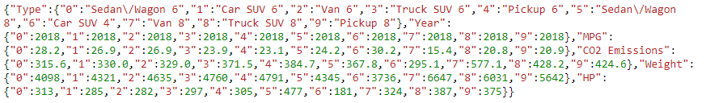

`json` has its own library, so we begin below by importing this to use in conjunction with pandas.

```python
import json

cars_json = pd.read_json('cars.json')

# Determine the data type of 'cars_json'
type(cars_json)

# Look at first 3 records
cars_json.head(3)

# Display the file info
cars_json.info()
```

```
pandas.core.frame.DataFrame
```

|  | Type | Year | MPG | CO2 Emissions | Weight | HP |
| --- | --- | --- | --- | --- | --- | --- |
| 0 | Sedan/Wagon 6 | 2018 | 28.2 | 315.6 | 4098 | 313 |
| 1 | Car SUV 6 | 2018 | 26.9 | 330.0 | 4321 | 285 |
| 2 | Van 6 | 2018 | 26.9 | 329.0 | 4635 | 282 |

```
<class 'pandas.core.frame.DataFrame'>
Int64Index: 10 entries, 0 to 9
Data columns (total 6 columns):
 #   Column         Non-Null Count  Dtype
---  ------         --------------  -----
 0   Type           10 non-null     object
 1   Year           10 non-null     int64
 2   MPG            10 non-null     float64
 3   CO2 Emissions  10 non-null     float64
 4   Weight         10 non-null     int64
 5   HP             10 non-null     int64
dtypes: float64(2), int64(3), object(1)
memory usage: 560.0+ bytes
```

## Adding a Column to the DataFrame

We want to create a new field for Cylinders. We know that the last character of **Type** contains the cylinders so let's isolate that using *slice()*.

```python
# Test out the use of slice
test = cars_json['Type'].str.slice(start=-1)
test
```

```
0    6
1    6
2    6
3    6
4    6
5    8
6    4
7    8
8    8
9    8
Name: Type, dtype: object
```

```python
# Add a new column to the dataframe
cars_json['Cylinders'] = cars_json['Type'].str.slice(start=-1)

# Inspect the dataframe to see the new column
cars_json.info()
cars_json.head()
```

```
<class 'pandas.core.frame.DataFrame'>
Int64Index: 10 entries, 0 to 9
Data columns (total 7 columns):
 #   Column         Non-Null Count  Dtype
---  ------         --------------  -----
 0   Type           10 non-null     object
 1   Year           10 non-null     int64
 2   MPG            10 non-null     float64
 3   CO2 Emissions  10 non-null     float64
 4   Weight         10 non-null     int64
 5   HP             10 non-null     int64
 6   Cylinders      10 non-null     object
dtypes: float64(2), int64(3), object(2)
memory usage: 640.0+ bytes
```

|  | Type | Year | MPG | CO2 Emissions | Weight | HP | Cylinders |
| --- | --- | --- | --- | --- | --- | --- | --- |
| 0 | Sedan/Wagon 6 | 2018 | 28.2 | 315.6 | 4098 | 313 | 6 |
| 1 | Car SUV 6 | 2018 | 26.9 | 330.0 | 4321 | 285 | 6 |
| 2 | Van 6 | 2018 | 26.9 | 329.0 | 4635 | 282 | 6 |
| 3 | Truck SUV 6 | 2018 | 23.9 | 371.5 | 4760 | 297 | 6 |
| 4 | Pickup 6 | 2018 | 23.1 | 384.7 | 4791 | 305 | 6 |

```python
# Cylinders needs to be an integer
cars_json['Cylinders'] = cars_json['Cylinders'].astype(int)

# Inspect the data again to confirm 'Cylinders' is an int type
cars_json.info()
```

```
<class 'pandas.core.frame.DataFrame'>
Int64Index: 10 entries, 0 to 9
Data columns (total 7 columns):
 #   Column         Non-Null Count  Dtype
---  ------         --------------  -----
 0   Type           10 non-null     object
 1   Year           10 non-null     int64
 2   MPG            10 non-null     float64
 3   CO2 Emissions  10 non-null     float64
 4   Weight         10 non-null     int64
 5   HP             10 non-null     int64
 6   Cylinders      10 non-null     int64
dtypes: float64(2), int64(4), object(1)
memory usage: 640.0+ bytes
```

### Writing to a File

When you create a new column and add it to your dataframe, it is a good idea to write out the new file to save it for future reference.

**Problem 6 (4 pts.)**: Create a new column called Cylinder_efficiency and add it to the cars_json DataFrame. The calculation for Cylinder_efficiency will be HP divided by the Cylinders; round the results to two decimal places. Next write your new file out to an **Excel** file called cars_totals.xlsx. Upload your new file into Canvas along with the .ipynb and HTML files. Reference: __[Pandas DataFrame to Excel File](https://pandas.pydata.org/pandas-docs/stable/reference/api/pandas.DataFrame.to_excel.html)__

```python
#TODO: Create a new column called Cylinder_efficiency and add it to the cars_json DataFrame
cars_json['Cylinder_efficiency']=round(cars_json['HP']/cars_json['Cylinders'],2)

#TODO: Show the first five rows of your file
cars_json.head()

#TODO: Write your file to an Excel file called 'cars_totals.xlsx'

### I wasnt sure if I should remove the index from the dataframe while writing to excel. But in my experience no one wants a pandas index column on their workbook as excel has its own indexer starting at 1. So I removed it.
### I shall accept ye grading judgement on this matter with grace.
cars_json.to_excel('cars_totals.xlsx', index=False)
```

|  | Type | Year | MPG | CO2 Emissions | Weight | HP | Cylinders | Cylinder_efficiency |
| --- | --- | --- | --- | --- | --- | --- | --- | --- |
| 0 | Sedan/Wagon 6 | 2018 | 28.2 | 315.6 | 4098 | 313 | 6 | 52.17 |
| 1 | Car SUV 6 | 2018 | 26.9 | 330.0 | 4321 | 285 | 6 | 47.50 |
| 2 | Van 6 | 2018 | 26.9 | 329.0 | 4635 | 282 | 6 | 47.00 |
| 3 | Truck SUV 6 | 2018 | 23.9 | 371.5 | 4760 | 297 | 6 | 49.50 |
| 4 | Pickup 6 | 2018 | 23.1 | 384.7 | 4791 | 305 | 6 | 50.83 |

### Viewing File Contents

On a side note, though you can easily view the contents of any text file using your favorite text editor, there are ways of doing this using Python. Here we are going to use the shell command appropriate to your operating system. To access the shell commands from within Jupyter notebook we need to prefix them with the `!` character.

```python
import platform

if (platform.system() == 'Windows'):
    !type cars.txt
else:
    !cat cars.txt
```

```
Sedan/Wagon/6 2018 28.2 315.6 4098 313
CarSUV/6 2018 26.9 330 4321 285
Van/6 2018 26.9 329 4635 282
TruckSUV/6 2018 23.9 371.5 4760 297
Pickup/6 2018 23.1 384.7 4791 305
Sedan/Wagon/8 2018 24.2 367.8 4345 477
CarSUV/4 2018 30.2 295.1 3736 181
Van/8 2018 15.4 577.1 6647 324
TruckSUV/8 2018 20.8 428.2 6031 387
Pickup/8 2018 20.9 424.6 5642 375
```